# TAD PPOL 6801 - Problem Set 01

Amber

2025-02-03

## Problem Set 01

I am using the tweets dataset.

```r
tweets <- read_csv("tweets_congress.csv")
```

### Question 1

Take a **sample** of your documents and read them carefully. This sample does not need to be random. Choose documents that are interesting to you or closely related to your theoretical interest. What are your thoughts after reading these documents? What did you learn from the sample? What stood out to you?

#### Filter, subset and read my documents

```r
# filter all tweets from democrats
tweets_dem <- tweets %>%
  filter(Party == "D")
head(tweets_dem)
```

```
## # A tibble: 6 × 10
##   author       text  date  bios  retweet_author Name  Link  State Party congress
##   <chr>        <chr> <chr> <chr> <chr>          <chr> <chr> <chr> <chr> <chr>
## 1 BennieGThom… "RT … Sat … Husb… DerrickNAACP   Thom… http… MS    D     House
## 2 BennieGThom… "Wis… Sat … Husb… <NA>           Thom… http… MS    D     House
## 3 BennieGThom… "Let… Sat … Husb… <NA>           Thom… http… MS    D     House
## 4 BennieGThom… "Thi… Wed … Husb… <NA>           Thom… http… MS    D     House
## 5 BennieGThom… "RT … Wed … Husb… POTUS          Thom… http… MS    D     House
## 6 BennieGThom… "RT … Tue … Husb… January6thCmte Thom… http… MS    D     House
```

```r
# Dataset too large. Create a subset.
set.seed(1) # Ensure we get the same ouput of a randomization
tweets_dem_sub <- tweets_dem %>%
  sample_n(50000) # Create a subset of 50000 observations

# randomly read 10 rows
set.seed(2)
tweets_dem_sub %>%
  sample_n(10)
```

```
## # A tibble: 10 × 10
##    author      text  date  bios  retweet_author Name  Link  State Party congress
##    <chr>       <chr> <chr> <chr> <chr>          <chr> <chr> <chr> <chr> <chr>
##  1 RepJuanVar… "FAQ… Tue … "Off… <NA>           Varg… http… CA    D     House
##  2 SenatorCan… "I’m… Fri … "U.S… <NA>           Cant… http… WA    D     senate
##  3 RepAnnieKu… "Hea… Fri … "Hon… <NA>           Kust… http… NH    D     House
##  4 RepDavidTr… "Thi… Tue … "Con… <NA>           Tron… http… MD    D     House
##  5 RepCicilli… "Mor… Mon … "Twe… <NA>           Cici… http… RI    D     House
##  6 jahimes     "RT … Wed … "Con… PaulBegala     Hime… http… CT    D     House
##  7 RepMcNerney "It … Wed … "Pro… <NA>           McNe… http… CA    D     House
##  8 SenatorCar… "On … Wed … "US … <NA>           Card… http… MD    D     senate
##  9 SenStabenow "Sin… Wed … "Rep… <NA>           Stab… http… MI    D     senate
## 10 RepBonnie   "RT … Fri … "Pro… GovMurphy      Wats… http… NJ    D     House
```

From the data side, these documents are long and messy, containing texts and author information. These texts include a lot of emojis, mentions , hash tags, and URLs which can make pre-processing complicated. These also include HTML escape characters like &amp which should be “&” and line breaks ().

From the content side, after reading the tweets from some of the democrats, I found out they brought up a lot frequently mentioned issues that democrats care about, including “LGBTQIA+”, “BorderWall”,“newest citizen”,“Covid-19”, etc. These relate to political topic like immigration policy, government spending, and civic engagement. We can also see some strong sentiments behind these tweets by looking at words like “useless” and “congrats”.

### Question 2

**Tokenize** your documents and **pre-process** them, removing any “extraneous” content you noticed in closely reading a sample of your documents. What content did you remove and why? Are there any preprocessing steps (from class) that you decided not to use? Why?

#### Create a corpus

```r
# Convert the dataset into a corpus
tweets_corpus <- corpus(tweets_dem_sub, text_field = "text")
summary(tweets_corpus, n =5) # Look at the first 5 documents
```

```
## Corpus consisting of 50000 documents, showing 5 documents:
##
##   Text Types Tokens Sentences        author                           date
##  text1    27     29         1  RepSusanWild Mon Apr 06 21:15:08 +0000 2020
##  text2    21     22         2        RepMGS Thu May 13 16:25:00 +0000 2021
##  text3    24     27         1  RepAndyKimNJ Sat Feb 27 16:48:02 +0000 2021
##  text4    23     24         2  repmarkpocan Wed Mar 31 18:23:01 +0000 2021
##  text5    21     25         1 SenGaryPeters Tue Apr 28 16:36:49 +0000 2020
##                                                                                                                                                              bios
##                                                                                                      Proud to represent Pennsylvania's 7th Congressional District
##                                  Representing Pennsylvania's 5th Congressional District. Vice Chair of @HouseAdm_Dems. Member of @HouseJudiciary @RulesDemocrats.
##  Husband to my college sweetheart. Father to two troublemaking baby boys. Congressman for New Jersey's Third District. All tweets from Congressman Kim signed –AK
##  Honored to serve the people of Wisconsin's 2nd District. \nCo-Chair of @Labor_Caucus & @LGBTEqCaucus 🏳️‍🌈. \nMember of @AppropsDems & @EdLaborCmte. \nHe/Him/His.
##                                                  U.S. Senator proudly representing the state of Michigan. For federal resources on the Coronavirus click here ⬇️⬇️⬇️
##  retweet_author              Name                              Link State Party
##            <NA>       Wild, Susan  https://twitter.com/RepSusanWild    PA     D
##            <NA> Scanlon, Mary Gay        https://twitter.com/RepMGS    PA     D
##            <NA>         Kim, Andy  https://twitter.com/RepAndyKimNJ    NJ     D
##    LGBTEqCaucus       Pocan, Mark  https://twitter.com/repmarkpocan    WI     D
##            <NA>   Peters, Gary C. https://twitter.com/SenGaryPeters    MI     D
##  congress
##     House
##     House
##     House
##     House
##    senate
```

#### Tokenize

```r
# Tokenize the corpus
dem_tokens <- tokens(tweets_corpus, remove_punct = TRUE, remove_numbers = TRUE) %>% # Remove punctuation and numbers
  tokens_tolower() %>% # Convert all tokens to lower case
  tokens_remove(c(stopwords("en"), "madam", "mr", "today","rt")) %>% # Remove common English stopwords, retweets identifier and frequetly appeared meaningless words
  tokens_remove(pattern = "#*|@*") %>%  # Remove hashtags and handles
  tokens_remove(pattern = "^https://.*", valuetype = "regex") %>% # Remove web links
  tokens_replace(pattern = "*'s|.*'m|.*'re|.*'d|.*'ve|.*'ll|.*n't", replacement = "") %>%
  tokens_remove(c("amp","$")) %>% # Remove HTML escape characters
  tokens_wordstem() # Word stemming

# Look at the first few tokenized texts
head(dem_tokens)
```

```
## Tokens consisting of 6 documents and 9 docvars.
## text1 :
##  [1] "know"        "mani"        "laid"        "b"           "c"
##  [6] "find"        "new"         "sourc"       "incom"       "even"
## [11] "temporarili"
##
## text2 :
##  [1] "neither" "stigmat" "poor"    "leav"    "vulner"  "resent"  "special"
##  [8] "benefit" "say"     "instead"
##
## text3 :
##  [1] "rescu"     "kid"       "we’r"      "readi"     "kid"       "go"
##  [7] "back"      "school"    "in-person" "make"      "sure"      "school"
##
## text4 :
## [1] "check"   "along"   "show"    "support" "tran"    "peopl"
##
## text5 :
##  [1] "michigan" "hospit"   "health"   "care"     "provid"   "sever"
##  [7] "financi"  "strain"   "due"      "covid-19" "struggl"  "keep"
## [ ... and 1 more ]
##
## text6 :
## [1] "believ"     "whole"      "russia"     "investig"   "fraud"
## [6] "witch-hunt" "rod"        "rosenstein"
```

During my tokenization and preprocessing, I first tokenized my corpus by removing punctuation and numbers and converting all tokens to lowercase. I removed common English stop words like “and” and meaningless words like “mr” that often appear in political contents. I also removed hash tags (#), mentions (@) , re-tweets and website links starting with “https”. After I glimpsed the tokens and found out that there are a lot of words “amp” which can be resulted from HTML escape characters like &amp, I removed all “amp”. Besides, I used word stemming to reduce duplicated words and reduce the dataset size for faster analysis later on.

I didn’t use n-grams because I don’t think it makes sense to make all individual tokens into, say, bi-grams as some words might make sense but most of them won’t.

### Question 3

Pick an important **source of variation** in your data (e.g. date, author identity, location, etc.). **Subset** your data along this dimension and create word clouds for each category. e.g. a male vs. female author word cloud, a before and after a particular date word cloud, etc. What differences do you notice in the word clouds?

#### Subset my data along location, tokenize and preprocess

```r
# Subset my original dataset by states that are in the West
tweets_west <- tweets %>%
  filter(State == "CA" | State == "WA" | State == "OR" | State == "AK" | State == "HI"
         | State == "MT" | State == "ID" | State == "WY" | State == "NV" | State == "UT"
         | State == "CO" | State == "AZ" | State == "NM")

# Subset my original dataset by states that are in the Northeast
tweets_east <- tweets %>%
  filter(State == "ME" | State == "NH" | State == "VT" | State == "MA" | State == "RI"
         | State == "CT" | State == "NY" | State == "NJ" | State == "PA")

# Create corpus for both
west_corpus <- corpus(tweets_west, text_field = "text")
east_corpus <- corpus(tweets_east, text_field = "text")

# Tokenize both corpuses

## West
west_tokens <- tokens(west_corpus, remove_punct = TRUE, remove_numbers = TRUE) %>% # Remove punctuation and numbers
  tokens_tolower() %>% # Convert all tokens to lower case
  tokens_remove(c(stopwords("en"), "madam", "mr", "today","rt")) %>% # Remove common English stopwords, retweets identifier and frequetly appeared meaningless words
  tokens_remove(pattern = "#*|@*") %>%  # Remove hashtags and handles
  tokens_remove(pattern = "^https://.*", valuetype = "regex") %>% # Remove web links
  tokens_replace(pattern = "*'s|.*'m|.*'re|.*'d|.*'ve|.*'ll|.*n't", replacement = "") %>%
  tokens_remove(c("amp","$")) %>% # Remove HTML escape characters
  tokens_wordstem() # Word stemming

## Northeast
east_tokens <<- tokens(east_corpus, remove_punct = TRUE, remove_numbers = TRUE) %>% # Remove punctuation and numbers
  tokens_tolower() %>% # Convert all tokens to lower case
  tokens_remove(c(stopwords("en"), "madam", "mr", "today","rt")) %>% # Remove common English stopwords, retweets identifier and frequetly appeared meaningless words
  tokens_remove(pattern = "#*|@*") %>%  # Remove hashtags and handles
  tokens_remove(pattern = "^https://.*", valuetype = "regex") %>% # Remove web links
  tokens_replace(pattern = "*'s|.*'m|.*'re|.*'d|.*'ve|.*'ll|.*n't", replacement = "") %>%
  tokens_remove(c("amp","$")) %>% # Remove HTML escape characters
  tokens_wordstem() # Word stemming

# Convert tokens to DFM
west_dfm <- west_tokens %>%
  dfm()

east_dfm <- east_tokens %>%
  dfm()

topfeatures(west_dfm)
```

```
## american     work    thank      act     need              join     help
##    18465    17161    15253    14621    14318    14025    13456    13248
##     year   famili
##    13181    12806
```

```r
topfeatures(east_dfm)
```

```
## american     work    thank      new     join              hous      act
##    15307    13115    12300    12013    11439    11237    11084    10983
##     need     year
##    10528    10143
```

```r
# I didn't trim my tokens here because it still removed all features - couldn't find a way to figure it out.
```

#### Create word clouds for comparison

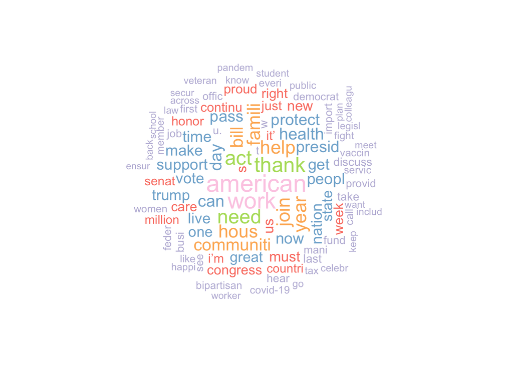

```r
# Load package necessary to create word clouds
pacman::p_load(quanteda.textplots)

# Create a word cloud for democrats' tweets from the West

wcWest <- textplot_wordcloud(west_dfm, random_order = FALSE,
                   rotation = .25, max_words = 100,
                   min_size = 0.5, max_size = 2.8,
                   color = RColorBrewer::brewer.pal(8, "Set3"))
```

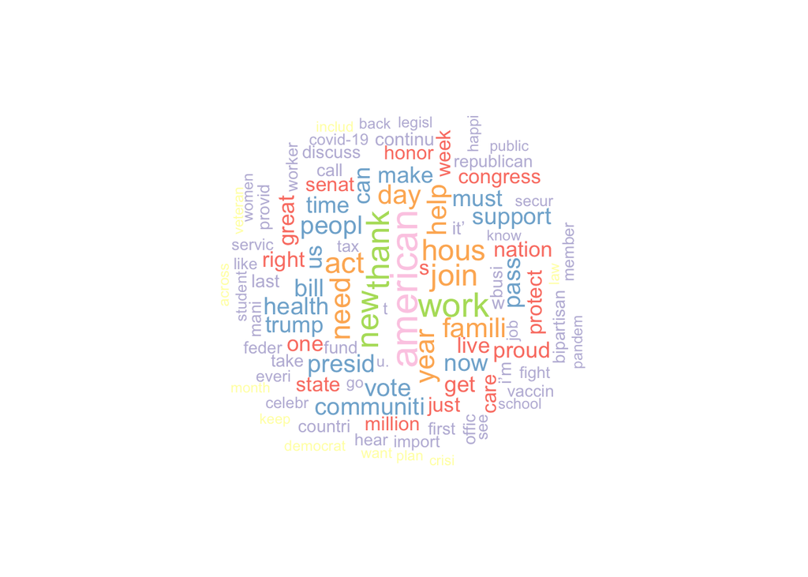

```r
# Create a word cloud for democrats' tweets from the Northeast

wcEast <- textplot_wordcloud(east_dfm, random_order = FALSE,
                   rotation = .25, max_words = 100,
                   min_size = 0.5, max_size = 2.8,
                   color = RColorBrewer::brewer.pal(8, "Set3"))
```

### Question 4

**Subset** your data along the same variation and **identify words that discriminate between groups**. You can do this by using **TF-IDF** or create a measure similar to Ban’s article (“How Newspapers Reveal Political Power”).

#### Compute TF-IDF for my data for both groups

```r
pacman::p_load(quanteda.textstats)

# Proportional TF and log-scaled IDF for West
tfidf_west <- west_dfm %>%
  dfm_tfidf(scheme_tf = "prop", scheme_df = "inversemax")

# Proportional TF and log-scaled IDF for Northeast
tfidf_east <- east_dfm %>%
  dfm_tfidf(scheme_tf = "prop", scheme_df = "inversemax")

# Get top words for states in the West
top_west <- textstat_frequency(tfidf_west, n = 10, force = TRUE)  # Top 10 words
top_west <- top_west %>% select(feature, frequency)

# Get top words for states in the Northeast
top_east <- textstat_frequency(tfidf_east, n = 10, force = TRUE)  # Top 10 words
top_east <- top_east %>% select(feature, frequency)

# This gives us top words that are most distinctive for each group based on TF-IDF values.

print(top_west)
```

```
##      feature frequency
## 1      happi  406.1046
## 2       read  336.2702
## 3  congratul  328.5367
## 4     celebr  325.9912
## 5    discuss  320.2233
## 6         go  319.1399
## 7   colleagu  311.5819
## 8     vaccin  309.5710
## 9     import  308.9191
## 10     proud  306.2001
```

```r
print(top_east)
```

```
##      feature frequency
## 1       read  320.7691
## 2      happi  308.0716
## 3     celebr  268.9937
## 4       tune  266.2345
## 5    discuss  265.4166
## 6         go  264.0392
## 7  statement  262.4312
## 8     import  261.0206
## 9     vaccin  258.6883
## 10     great  256.6141
```

### Question 5

Create or use an **existing dictionary** to measure a topic of interest (e.g.,sentiment, tone, misinformation). **Label** your documents and **visualize** the prevalence of your classes.

```r
# Here I used VADER as it is useful for sentiment analysis on social media contents like tweets.
library(vader)

# Change tokens into a character vector
dem_tokens_v <- unlist(dem_tokens)

# Get the sentiment for each tokens
dem_sentiment <- tibble(
  word = dem_tokens_v,
  compound_score = sapply(dem_tokens_v, function(w) get_vader(w)[["compound"]])
)

# Write a function to tidy the results
get_vader_tidy <- function(dem_tokens_v){
  get_vader(dem_tokens_v) %>%
    tibble(outcomes=names(.),
           values=.)
}

# Apply VADER to the first 100 comments and store results in a tidy format
vader_outputs <- map(tweets_dem_sub$text[1:100], get_vader_tidy)

# Bind all outputs into a single data frame and merge with original dataset
dem_vader <- tweets_dem_sub %>%
  slice(1:100) %>%   # Keep only the first 1000 rows (matching `vader_outputs`)
  mutate(vader_output = vader_outputs) %>%   # Attach sentiment results
  unnest(vader_output)

# Filter for compound sentiment scores and select relevant columns (text, outcomes and values)
dem_vader_fil <- dem_vader %>%
  filter(outcomes == "compound") %>%
  select(text, outcomes, values)
head(dem_vader_fil)
```

```
## # A tibble: 6 × 3
##   text                                                           outcomes values
##   <chr>                                                          <chr>    <chr>
## 1 "I know that for so many who have been laid off b/c of #COVID… compound 0
## 2 "“It neither stigmatizes the poor nor leaves them vulnerable … compound 0.683
## 3 "RESCUE OUR KIDS - we’re all ready for our kids to go back to… compound 0.736
## 4 "RT @LGBTEqCaucus: Check it out! The @LGBTEqCaucus along with… compound 0.457
## 5 "Michigan hospitals &amp; health care providers are under sev… compound -0.34
## 6 "Me: Do you believe the whole Russia investigation was a frau… compound -0.718
```

```r
# Sort from highest to lowest sentiment score
sorted_sentiment <- dem_vader_fil %>%
  arrange(desc(values))
head(sorted_sentiment)
```

```
## # A tibble: 6 × 3
##   text                                                           outcomes values
##   <chr>                                                          <chr>    <chr>
## 1 "“We do not serve one party or one interest, but we serve one… compound 0.874
## 2 "I was happy to help Tommy from @boyscouts Troop 1518 complet… compound 0.859
## 3 "Had great time @memgrizz victory in DC over the improved @Wa… compound 0.802
## 4 "RT @ProtectCareNH: Share an ACA health care story: Senator H… compound 0.796
## 5 "RT @RepCasten: The #IPCCReport made clear we’re running out … compound 0.785
## 6 "Washington state continues to make great progress towards ge… compound 0.785
```

```r
# Label my documents
sorted_sentiment <- sorted_sentiment %>%
  mutate(sentiment = case_when(
    values > 0  ~ "positive",
    values < 0  ~ "negative",
    values == 0 ~ "neutral"
  ))

# Merge labels to my original dataset
merged_dem_vader <- left_join(dem_vader_fil, sorted_sentiment, by = "text")
head(merged_dem_vader)
```

```
## # A tibble: 6 × 6
##   text                         outcomes.x values.x outcomes.y values.y sentiment
##   <chr>                        <chr>      <chr>    <chr>      <chr>    <chr>
## 1 "I know that for so many wh… compound   0        compound   0        neutral
## 2 "“It neither stigmatizes th… compound   0.683    compound   0.683    positive
## 3 "RESCUE OUR KIDS - we’re al… compound   0.736    compound   0.736    positive
## 4 "RT @LGBTEqCaucus: Check it… compound   0.457    compound   0.457    positive
## 5 "Michigan hospitals &amp; h… compound   -0.34    compound   -0.34    negative
## 6 "Me: Do you believe the who… compound   -0.718   compound   -0.718   negative
```

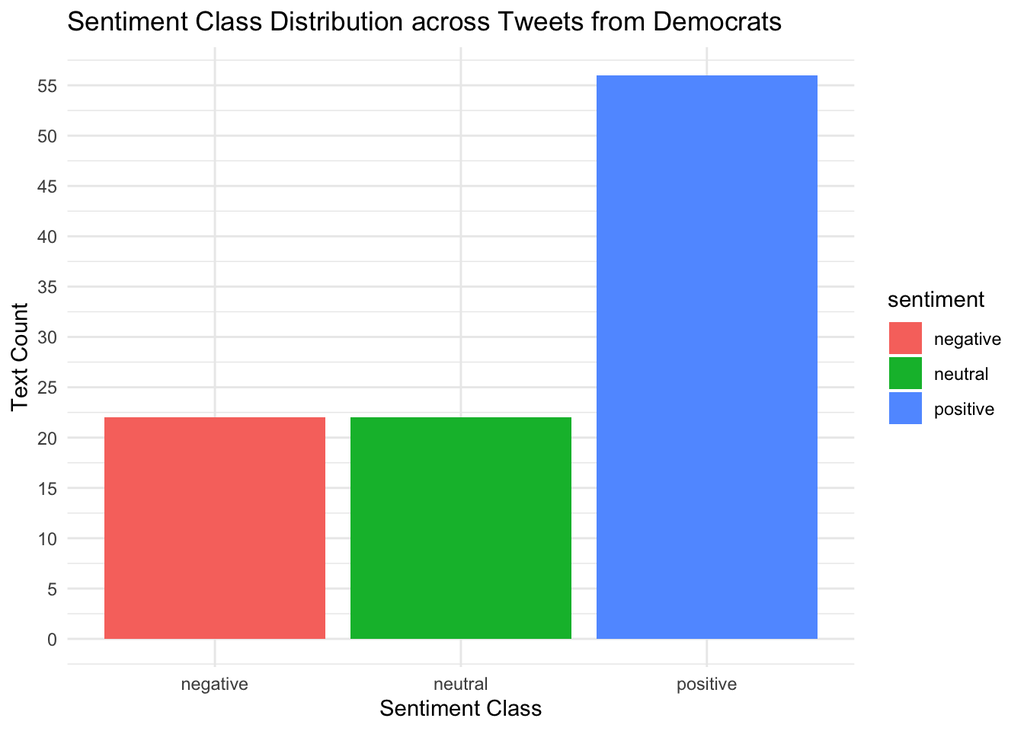

```r
# Count sentiment classes
sent_counts <- sorted_sentiment %>%
  count(sentiment)

# Create a bar plot to visualize the appearance of class
ggplot(sent_counts, aes(x = sentiment, y = n, fill = sentiment)) +
  geom_col() +
  labs(title = "Sentiment Class Distribution across Tweets from Democrats", x = "Sentiment Class", y = "Text Count") +
  scale_y_continuous(breaks = seq(0, 60, by = 5)) +
  theme_minimal()
```

### Question 6

Choose at least 10 documents that clearly (with high probability) represent each class in your classification dictionary (e.g. sports, politics,technology.)

#### Q 6.2

Using **cosine similarity**, find the 10 documents **closest to each reference document** from the ones you read above. Read those. How well does cosine similarity work in identifying similar documents? Try using another distance measure and compare the results. Anything interesting there?

```r
# Arrange with descending compound score
merged_dem_vader <- merged_dem_vader %>%
  arrange(desc(values.y))

# Convert to matrix
vader_dfm_matrix <- merged_dem_vader %>%
  corpus() %>%
  tokens() %>%
  dfm() %>%
  as.matrix()

# Extract vectors for reference documents
mostpos <- vader_dfm_matrix["text1", ] # most positive
mostneg <- vader_dfm_matrix["text100", ] # most negative

# Function to calculate cosine similarity
calculate_cosine_similarity <- function(vec1, vec2) {
  dot_product <- sum(vec1 * vec2)
  magn1 <- sqrt(sum(vec1^2))
  magn2 <- sqrt(sum(vec2^2))
  return(dot_product / (magn1 * magn2))
}

# [Cosine similarity] Distance and similarity with reference to the most positive one
cosine_scores_pos <- apply(vader_dfm_matrix, 1, function(text) calculate_cosine_similarity(text, mostpos))
cosine_results_pos <- data.frame(text = rownames(vader_dfm_matrix), cosine_similarity = cosine_scores_pos)

# Identify the 10 closet documents to the most positive

top10pos_co <- cosine_results_pos %>%
  arrange(desc(cosine_similarity)) %>%  # Sort in descending order
  slice(1:10)
print(top10pos_co)
```

```
##          text cosine_similarity
## text1   text1         1.0000000
## text86 text86         0.2174794
## text61 text61         0.2003273
## text7   text7         0.1793740
## text78 text78         0.1752499
## text21 text21         0.1696752
## text70 text70         0.1581930
## text60 text60         0.1551729
## text75 text75         0.1504237
## text39 text39         0.1500751
```

```r
# [Cosine similarity] Distance and similarity with reference to the most negative one
cosine_scores_neg <- apply(vader_dfm_matrix, 1, function(text) calculate_cosine_similarity(text, mostneg))
cosine_results_neg <- data.frame(text = rownames(vader_dfm_matrix), cosine_similarity = cosine_scores_neg)

# Identify the 10 closet documents to the most negative

top10neg_co <- cosine_results_neg %>%
  arrange(desc(cosine_similarity)) %>%  # Sort in descending order
  slice(1:10)
print(top10neg_co)
```

```
##            text cosine_similarity
## text100 text100         1.0000000
## text96   text96         0.2558409
## text88   text88         0.2514474
## text42   text42         0.2267787
## text57   text57         0.2088932
## text17   text17         0.2000000
## text44   text44         0.2000000
## text89   text89         0.2000000
## text49   text49         0.1924501
## text87   text87         0.1889822
```

**Cosine Similarity** focuses on the direction of text vectors rather than their magnitude, making it useful for comparing documents of different lengths.

```r
# Function to calculate Euclidean distance between two vectors
calculate_euclidean_distance <- function(vec1, vec2) {
  ec_distance <- sqrt(sum((vec1 - vec2)^2)) # Euclidean formula
  return(ec_distance)
}

# [Euclidean similarity] Distance and similarity with reference to the most positive one
eu_scores_pos <- apply(vader_dfm_matrix, 1, function(text) calculate_euclidean_distance(text, mostpos))
eu_results_pos <- data.frame(text = rownames(vader_dfm_matrix), euclidean_similarity = eu_scores_pos)

# Identify the 10 closet documents to the most positive

top10pos_eu <- eu_results_pos %>%
  arrange(desc(euclidean_similarity)) %>%  # Sort in descending order
  slice(1:10)
print(top10pos_eu)
```

```
##          text euclidean_similarity
## text60 text60             8.831761
## text64 text64             8.426150
## text21 text21             8.306624
## text13 text13             8.246211
## text75 text75             8.246211
## text91 text91             8.246211
## text8   text8             8.185353
## text59 text59             8.185353
## text82 text82             8.185353
## text98 text98             8.185353
```

```r
# [Euclidean similarity] Distance and similarity with reference to the most negative one
eu_scores_neg<- apply(vader_dfm_matrix, 1, function(text) calculate_euclidean_distance(text, mostneg))
eu_results_neg <- data.frame(text = rownames(vader_dfm_matrix), euclidean_similarity = eu_scores_neg)

# Identify the 10 closet documents to the most negative

top10neg_eu <- eu_results_neg %>%
  arrange(desc(euclidean_similarity)) %>%  # Sort in descending order
  slice(1:10)
print(top10neg_eu)
```

```
##          text euclidean_similarity
## text60 text60             8.485281
## text13 text13             7.745967
## text21 text21             7.681146
## text98 text98             7.549834
## text1   text1             7.483315
## text75 text75             7.483315
## text91 text91             7.483315
## text59 text59             7.416198
## text82 text82             7.416198
## text8   text8             7.280110
```

```r
# Combine cosine and Euclidean similarity results for positive reference
top10pos_combined <- bind_rows(
  top10pos_co %>% mutate(similarity_type = "cosine"),
  top10pos_eu %>% mutate(similarity_type = "euclidean")
)
print(top10pos_combined)
```

```
##               text cosine_similarity similarity_type euclidean_similarity
## text1        text1         1.0000000          cosine                   NA
## text86      text86         0.2174794          cosine                   NA
## text61      text61         0.2003273          cosine                   NA
## text7        text7         0.1793740          cosine                   NA
## text78      text78         0.1752499          cosine                   NA
## text21...6  text21         0.1696752          cosine                   NA
## text70      text70         0.1581930          cosine                   NA
## text60...8  text60         0.1551729          cosine                   NA
## text75...9  text75         0.1504237          cosine                   NA
## text39      text39         0.1500751          cosine                   NA
## text60...11 text60                NA       euclidean             8.831761
## text64      text64                NA       euclidean             8.426150
## text21...13 text21                NA       euclidean             8.306624
## text13      text13                NA       euclidean             8.246211
## text75...15 text75                NA       euclidean             8.246211
## text91      text91                NA       euclidean             8.246211
## text8        text8                NA       euclidean             8.185353
## text59      text59                NA       euclidean             8.185353
## text82      text82                NA       euclidean             8.185353
## text98      text98                NA       euclidean             8.185353
```

```r
# Combine cosine and Euclidean similarity results for negative reference
top10neg_combined <- bind_rows(
  top10neg_co %>% mutate(similarity_type = "cosine"),
  top10neg_eu %>% mutate(similarity_type = "euclidean")
)
print(top10neg_combined)
```

```
##            text cosine_similarity similarity_type euclidean_similarity
## text100 text100         1.0000000          cosine                   NA
## text96   text96         0.2558409          cosine                   NA
## text88   text88         0.2514474          cosine                   NA
## text42   text42         0.2267787          cosine                   NA
## text57   text57         0.2088932          cosine                   NA
## text17   text17         0.2000000          cosine                   NA
## text44   text44         0.2000000          cosine                   NA
## text89   text89         0.2000000          cosine                   NA
## text49   text49         0.1924501          cosine                   NA
## text87   text87         0.1889822          cosine                   NA
## text60   text60                NA       euclidean             8.485281
## text13   text13                NA       euclidean             7.745967
## text21   text21                NA       euclidean             7.681146
## text98   text98                NA       euclidean             7.549834
## text1     text1                NA       euclidean             7.483315
## text75   text75                NA       euclidean             7.483315
## text91   text91                NA       euclidean             7.483315
## text59   text59                NA       euclidean             7.416198
## text82   text82                NA       euclidean             7.416198
## text8     text8                NA       euclidean             7.280110
```

#### Q 6.3

Now, check these documents **qualitatively**. Look at the top features or **highest TF-IDF terms** in the documents you retrieved. Check **keywords in context**. Would you make any changes to your dictionary based on this analysis? If so, what and why?

```r
# Select the top 10 texts based on the highest cosine similarity scores
top10_texts_pos <- cosine_results_pos %>%
  arrange(desc(cosine_similarity)) %>% # Sort the results in descending order of cosine similarity
  slice(1:10) %>% # Select the top 10 entries
  pull(text)  # Extract text IDs

# Convert the merged_dem_vader dataframe into a corpus for text analysis
dem_vader_corpus <- merged_dem_vader %>%
  corpus()

# Subset the corpus to include only the documents that match the top 10 (most positive) text IDs
subset_corpus_vadar <- corpus_subset(dem_vader_corpus, docnames(dem_vader_corpus) %in% top10_texts_pos)

# Create a Document-Feature Matrix (DFM) and apply TF-IDF weighting
tfdif_vader_pos <- dfm(tokens(subset_corpus_vadar)) %>%
  dfm_tfidf(scheme_tf = "prop", scheme_df = "inversemax")

# Convert the TF-IDF weighted DFM into a data frame
tfidf_df_pos <- convert(tfdif_vader_pos, to = "data.frame")

# Reshape and sort the top terms by TF-IDF score
top_tfidf_terms <- tfidf_df_pos  %>%
  pivot_longer(-doc_id, names_to = "term", values_to = "tfidf") %>%
  arrange(desc(tfidf)) %>%
  slice(1:10)  # Select the 10 highest TF-IDF terms
print(top_tfidf_terms)
```

```
## # A tibble: 10 × 3
##    doc_id term              tfidf
##    <chr>  <chr>             <dbl>
##  1 text60 $                0.0774
##  2 text39 worth            0.0734
##  3 text1  one              0.0726
##  4 text1  serve            0.0707
##  5 text70 from             0.0568
##  6 text60 wage             0.0516
##  7 text39 for              0.0502
##  8 text78 met              0.0477
##  9 text78 with             0.0477
## 10 text78 @kerstinlundgren 0.0477
```

```r
# Define key words to search for in the text
patterns <- c("worth","one","serve","from","wage")

# Tokenize the first 10 texts from the merged_dem_vader dataframe
vader_tokens_toppos <- merged_dem_vader %>%
  slice(1:10) %>%
  corpus(text_field = "text") %>%
  tokens()

# Perform keyword-in-context (KWIC) search for the defined patterns within a window of 5 words
kwic_results_pos <- kwic(vader_tokens_toppos, pattern = patterns, window = 5)
print(kwic_results_pos)
```

```
## Keyword-in-context with 7 matches.
##   [text1, 5]                   “ We do not | serve |
##   [text1, 6]             “ We do not serve |  one  |
##   [text1, 9]        not serve one party or |  one  |
##  [text1, 14]          one interest, but we | serve |
##  [text1, 15]        interest, but we serve |  one  |
##   [text2, 7]       was happy to help Tommy | from  |
##  [text7, 11] led and transformed UMBC into |  one  |
##
##  one party or one interest
##  party or one interest,
##  interest, but we serve
##  one nation. ” I’m
##  nation. ” I’m glad
##  @boyscouts Troop 1518 complete his
##  of the best research institutions
```

I think sentiment analysis here using Vader is a bit weird, as I look at those key words and found out they are actually unrelated to sentiment. Those are more thematic words based on context, since, for example, serve shows strong thematic relevance like public service or civic duty. Therefore, if I would chnage my dictionary, I will change a topic dictionary.